# Lembar Jawaban UAS IS240 Praktek Probabilitas dan Statistika

Tuliskan nama anda di sini.

2021-05

Nama :Muhamad Aqil Naufal  
Kelas :IS 240 DL  
Kelompok :D6 NIM :00000051212  
Tanggal :2021-03  
Waktu :  
******************************************************

# 1 Petunjuk Umum

1. Gunakan template jurnal Infosys dari laman https://ejournals.umn.ac.id/index.php/SI untuk menuliskan laporan individu. Gunakan template markdown (.Rmd) yang telah disediakan untuk script anda.
2. File data disimpan dalam format MS Excel .xlsx. File laporan dalam format MS Word .docx.
3. Format nama file: NamaKelompok_Nama_NIM.extension, contoh: A3_KenDedes_0123456.Rmd.
4. Semua output harus dihasilkan oleh program R.
5. Semua file yang digunakan untuk menuliskan laporan ini dikumpulkan via elearning dengan zip relative path.
6. Setiap mahasiswa mengumpulkan sendiri-sendiri sesuai jadwal UAS.
7. **Pastikan file Rmd anda dapat dicompile dengan asumsi file data berada pada folder yang sama dengan script; jangan menggunakan absolute file path.** Bila anda menggunakan R package yang bukan merupakan package default R, tuliskan informasi mengenai package yang perlu diinstal. **File yang tidak dapat dicompile secara otomatis mendapatkan nilai 1 dari 100.**

# 2 Soal

## 2.1 (Bobot 10%) Kelengkapan dan Kesesuaian Format

File markdown script, file laporan dengan format jurnal Infosys dan file data dalam format yang telah ditentukan pada petunjuk ujian disubmit via e-learning.

## 2.2 (Bobot 10%) Impor Data dan Deskripsi Singkat Data

Impor data anda ke dalam R dengan asumsi file data berada pada folder yang sama dengan file script R anda. Tampilkan deskripsi singkat data anda.

*Jawaban*

```r
#a-----
#Import data
library(readxl)
Data <- read_excel("D6_MuhamadAqilNaufal_00000051213.xlsx", range = "B1:U210")

#b-------
#Tuliskan perintah R untuk menampilkan deskripsi singkat data anda.
str(Data)
```

```
## tibble [209 × 20] (S3: tbl_df/tbl/data.frame)
##  $ Nama                                                                                          : chr [1:209] "Ferrozio Wijaya" "Nasya Georgina Rompas" "E" "Jena" ...
##  $ Jenis kelamin                                                                                 : chr [1:209] "Laki-laki" "Perempuan" "Perempuan" "Perempuan" ...
##  $ Umur                                                                                          : num [1:209] 18 19 18 18 17 18 19 19 18 17 ...
##  $ Jenjang pendidikan                                                                            : chr [1:209] "Perguruan Tinggi" "Perguruan Tinggi" "Perguruan Tinggi" "Perguruan Tinggi" ...
##  $ Perangkat apa yang lebih sering anda gunakan untuk meeting?                                   : chr [1:209] "PC/Laptop" "PC/Laptop" "PC/Laptop" "PC/Laptop" ...
##  $ Platform video conference(VC) apa yang anda gunakan?                                          : chr [1:209] "Zoom" "Zoom" "Zoom, Google Meet/Hangouts" "Zoom" ...
##  $ Seberapa sering anda melakukan meeting dalam seminggu?                                        : chr [1:209] "1-5 kali" "6-10 kali" "6-10 kali" "6-10 kali" ...
##  $ Fitur apa yang paling berguna ketika meeting?                                                 : chr [1:209] "Share Screen, Breakout Room" "Share Screen, Breakout Room, Remote Control, Internal Recording" "Share Screen, Breakout Room, Remote Control" "Share Screen, Breakout Room" ...
##  $ Dimana biasanya anda melakukan meeting?                                                       : chr [1:209] "Rumah" "Rumah" "Rumah" "Rumah" ...
##  $ Sudah berapa lama anda menggunakan Video Conference(VC)                                       : chr [1:209] "3-9 bulan" "3-9 bulan" "3-9 bulan" "3-9 bulan" ...
##  $ Kendala apa yang paling sering anda alami selama meeting?                                     : chr [1:209] "Server Down" "Server Down" "Koneksi Tidak Stabil" "Koneksi Tidak Stabil" ...
##  $ Seberapa sering anda mengalami suatu masalah ketika meeting berlangsung                       : num [1:209] 3 3 3 3 4 3 3 3 3 3 ...
##  $ Jaringan apa yang anda gunakan?                                                               : chr [1:209] "Wi-fi" "Wi-fi" "Wi-fi" "Wi-fi" ...
##  $ Apakah anda merasa bosan dengan pembelajaran daring melalui Video Conference ?                : chr [1:209] "Ya" "Tidak" "Ya" "Ya" ...
##  $ Apakah pembelajaran melalui Video Conference membantu anda menjadi lebih aktif ketika kelas ? : num [1:209] 5 NA 3 3 4 4 3 4 3 1 ...
##  $ Menurut anda, seberapa layakkah penerapan pembelajaran daring di Indonesia?                   : num [1:209] 2 3 4 4 4 3 3 2 3 3 ...
##  $ Menurut anda, seberapa efektif penggunaan video conference terhadap suatu proses pembelajaran?: num [1:209] 1 2 4 4 3 2 3 3 3 3 ...
##  $ Menurut anda dengan adanya pembelajaran daring, apakah akan mempengaruhi nilai anda?          : chr [1:209] "Setuju" "Setuju" "Setuju" "Setuju" ...
##  $ Berikan alasannya jika anda tidak setuju. (jika anda setuju cukup tandai "-")                 : chr [1:209] "-" "-" "-" "-" ...
##  $ Jika mempengaruhi, nilai apa yang sekiranya anda dapatkan?                                    : num [1:209] 2 3 4 2 3 1 2 4 2 3 ...
```

```r
head(Data)
```

```
## # A tibble: 6 × 20
##   Nama         `Jenis kelamin`  Umur `Jenjang pendidikan` Perangkat apa yang l…¹
##   <chr>        <chr>           <dbl> <chr>                <chr>
## 1 Ferrozio Wi… Laki-laki          18 Perguruan Tinggi     PC/Laptop
## 2 Nasya Georg… Perempuan          19 Perguruan Tinggi     PC/Laptop
## 3 E            Perempuan          18 Perguruan Tinggi     PC/Laptop
## 4 Jena         Perempuan          18 Perguruan Tinggi     PC/Laptop
## 5 Fardhila Z   Perempuan          17 Perguruan Tinggi     PC/Laptop
## 6 Kelly Mae    Perempuan          18 Perguruan Tinggi     PC/Laptop
## # ℹ abbreviated name:
## #   ¹`Perangkat apa yang lebih sering anda gunakan untuk meeting?`
## # ℹ 15 more variables:
## #   `Platform video conference(VC) apa yang anda gunakan?` <chr>,
## #   `Seberapa sering anda melakukan meeting dalam seminggu?` <chr>,
## #   `Fitur apa yang paling berguna ketika meeting?` <chr>,
## #   `Dimana biasanya anda melakukan meeting?` <chr>, …
```

```r
tail(Data)
```

```
## # A tibble: 6 × 20
##   Nama  `Jenis kelamin`  Umur `Jenjang pendidikan` Perangkat apa yang lebih se…¹
##   <chr> <chr>           <dbl> <chr>                <chr>
## 1 <NA>  <NA>               NA <NA>                 <NA>
## 2 <NA>  <NA>               NA <NA>                 <NA>
## 3 <NA>  <NA>               NA <NA>                 <NA>
## 4 <NA>  <NA>               NA <NA>                 <NA>
## 5 <NA>  <NA>               NA <NA>                 <NA>
## 6 <NA>  <NA>               NA <NA>                 <NA>
## # ℹ abbreviated name:
## #   ¹`Perangkat apa yang lebih sering anda gunakan untuk meeting?`
## # ℹ 15 more variables:
## #   `Platform video conference(VC) apa yang anda gunakan?` <chr>,
## #   `Seberapa sering anda melakukan meeting dalam seminggu?` <chr>,
## #   `Fitur apa yang paling berguna ketika meeting?` <chr>,
## #   `Dimana biasanya anda melakukan meeting?` <chr>, …
```

```r
summary(Data)
```

```
##      Nama           Jenis kelamin           Umur       Jenjang pendidikan
##  Length:209         Length:209         Min.   :13.00   Length:209
##  Class :character   Class :character   1st Qu.:18.00   Class :character
##  Mode  :character   Mode  :character   Median :19.00   Mode  :character
##                                        Mean   :19.08
##                                        3rd Qu.:19.00
##                                        Max.   :99.00
##                                        NA's   :6
##  Perangkat apa yang lebih sering anda gunakan untuk meeting?
##  Length:209
##  Class :character
##  Mode  :character
##
##
##
##
##  Platform video conference(VC) apa yang anda gunakan?
##  Length:209
##  Class :character
##  Mode  :character
##
##
##
##
##  Seberapa sering anda melakukan meeting dalam seminggu?
##  Length:209
##  Class :character
##  Mode  :character
##
##
##
##
##  Fitur apa yang paling berguna ketika meeting?
##  Length:209
##  Class :character
##  Mode  :character
##
##
##
##
```

[output cut: 81 more lines]

```
##  Length:209
##  Class :character
##  Mode  :character
##
##
##
##
##  Jika mempengaruhi, nilai apa yang sekiranya anda dapatkan?
##  Min.   :1.000
##  1st Qu.:1.000
##  Median :2.000
##  Mean   :2.391
##  3rd Qu.:3.000
##  Max.   :5.000
##  NA's   :40
```

```r
#c-------
#library
library(moments)
```

## 2.3 (Bobot 30%) Eksplorasi data

### 2.3.1 (20%) Grafik

Gambarkan grafik yang sesuai untuk menggambarkan distribusi frekuensi semua variabel pada data anda. Bahaslah kategori dengan frekuensi tertinggi dan terendah. Apa yang dapat anda simpulkan? Gambarkan grafik sesuai untuk menggambarkan distribusi frekuensi variabel numerik pada data anda. Apakah distribusinya mengikuti distribusi probabilitas tertentu? Tunjukkan outlier (bila ada) pada gambar dan lakukan uji normalitas. Apa yang dapat anda simpulkan? (Bila semua data anda adalah data kategorikal, tuliskan “Tidak ada variabel numerik.”)

*Jawaban*

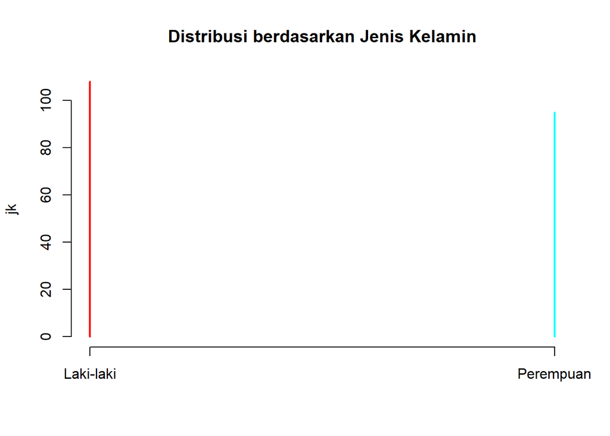

```r
#Grafik----

Data$`Jenis kelamin`<- as.factor(Data$`Jenis kelamin`)
jk <- table(Data$`Jenis kelamin`)
plot(jk, main = "Distribusi berdasarkan Jenis Kelamin",col=rainbow(2))
```

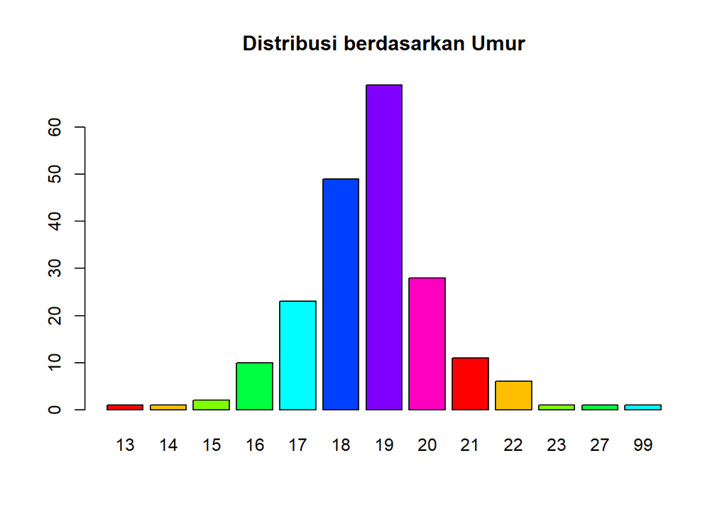

```r
par(mfrow = c(1,1))

Data$Umur <- as.factor(Data$Umur)
umur <- table(Data$ Umur)
barplot(umur,main = "Distribusi berdasarkan Umur",col = rainbow(8))
```

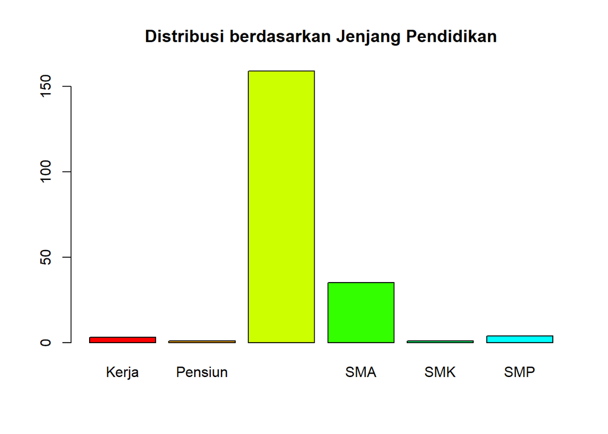

```r
JP <- table(Data$`Jenjang pendidikan`)
barplot(JP,main = "Distribusi berdasarkan Jenjang Pendidikan", col = rainbow(10))
```

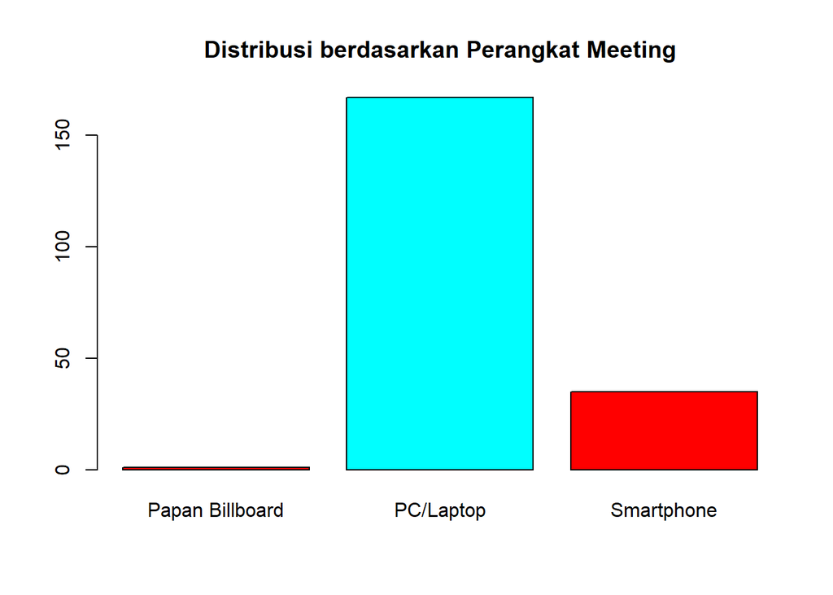

```r
Perangkat <- table(Data$`Perangkat apa yang lebih sering anda gunakan untuk meeting?`)
barplot(Perangkat,main = "Distribusi berdasarkan Perangkat Meeting",col = rainbow(2))
```

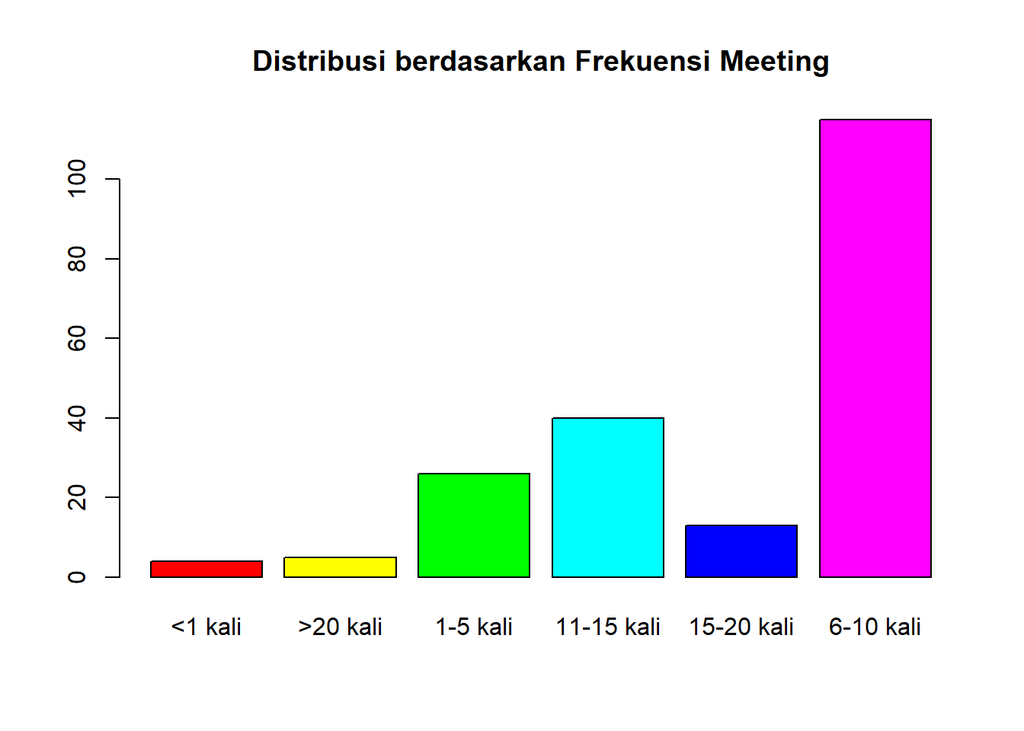

```r
Data$`Seberapa sering anda melakukan meeting dalam seminggu?` <- as.factor(Data$`Seberapa sering anda melakukan meeting dalam seminggu?`)
Totalmeet <- table(Data$`Seberapa sering anda melakukan meeting dalam seminggu?`)
barplot (Totalmeet,main = "Distribusi berdasarkan Frekuensi Meeting",col = rainbow(6))
```

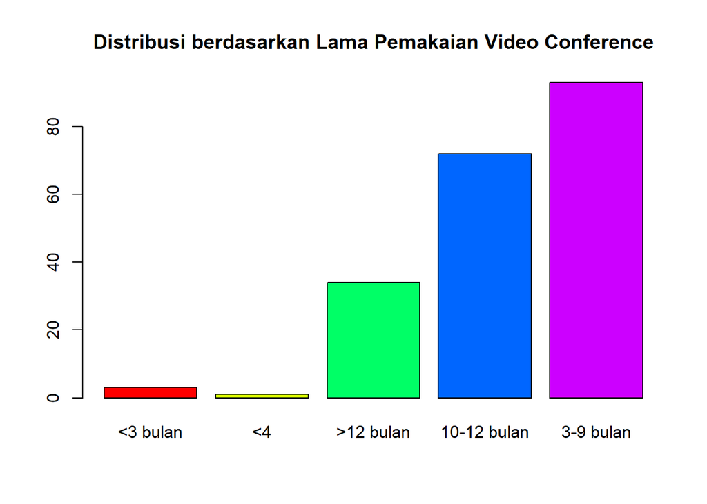

```r
Data$`Sudah berapa lama anda menggunakan Video Conference(VC)?` <- as.factor(Data$`Sudah berapa lama anda menggunakan Video Conference(VC)`)
lama <- table(Data$`Sudah berapa lama anda menggunakan Video Conference(VC)`)
barplot(lama,main = "Distribusi berdasarkan Lama Pemakaian Video Conference", col = rainbow(5))
```

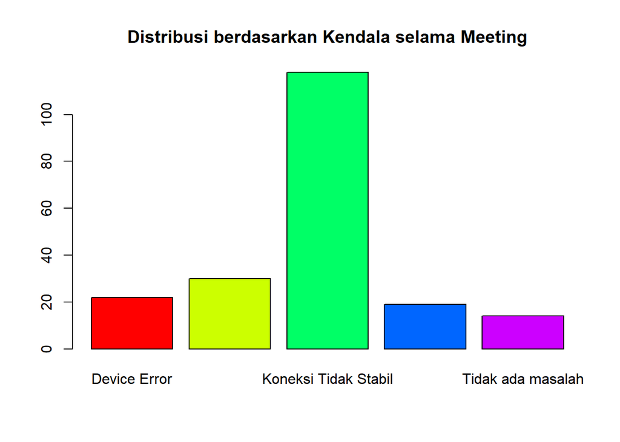

```r
kendala <- table(Data$ `Kendala apa yang paling sering anda alami selama meeting?`)
barplot(kendala , main = "Distribusi berdasarkan Kendala selama Meeting", col = rainbow(5))
```

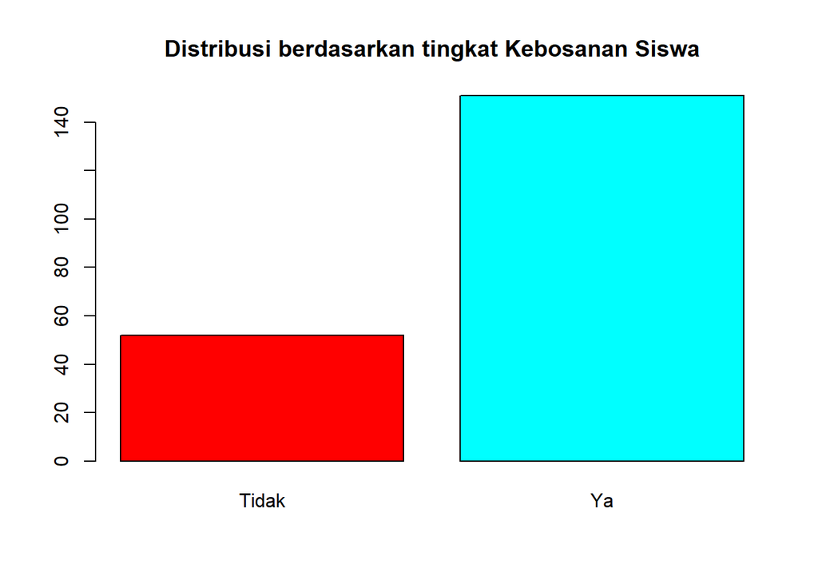

```r
bosan <- table(Data$`Apakah anda merasa bosan dengan pembelajaran daring melalui Video Conference ?`)
barplot (bosan,main = "Distribusi berdasarkan tingkat Kebosanan Siswa",col = rainbow(2))
```

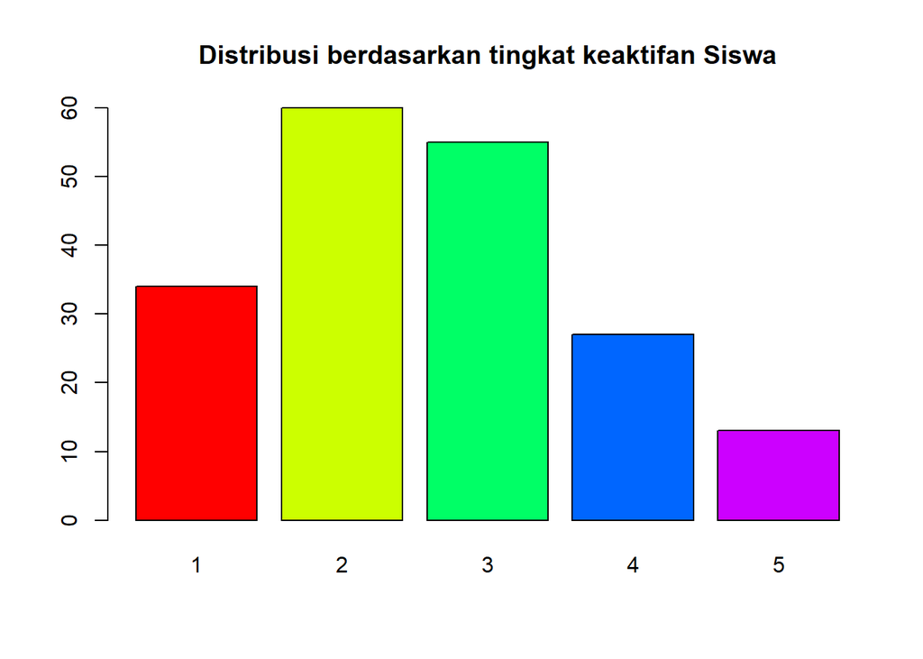

```r
aktif <- table(Data$`Apakah pembelajaran melalui Video Conference membantu anda menjadi lebih aktif ketika kelas ?`)
barplot (aktif,main = "Distribusi berdasarkan tingkat keaktifan Siswa",col = rainbow(5))
```

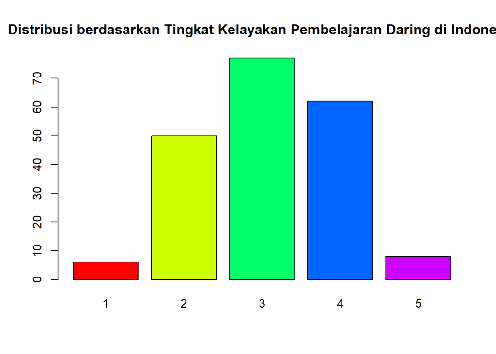

```r
kelayakan <- table(Data$`Menurut anda, seberapa layakkah penerapan pembelajaran daring di Indonesia?`)
barplot (kelayakan, main = "Distribusi berdasarkan Tingkat Kelayakan Pembelajaran Daring di Indonesia",col = rainbow(5))
```

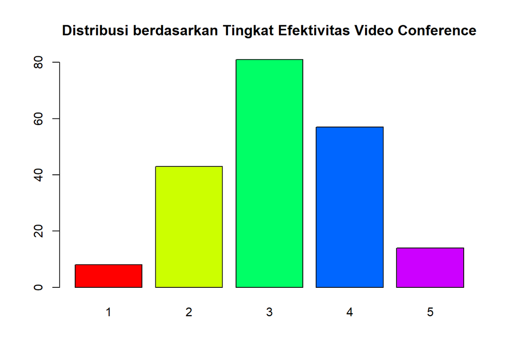

```r
efektif <- table(Data$`Menurut anda, seberapa efektif penggunaan video conference terhadap suatu proses pembelajaran?`)
barplot(efektif, main = "Distribusi berdasarkan Tingkat Efektivitas Video Conference",col = rainbow(5))
```